# HW4

This author section should be left blank empty for anonymous grading

Due 2024-02-28

## Instruction:

Once you have completed your answer, please submit both the knitted .html file and the .rmd file together.

### Question 1 (a)

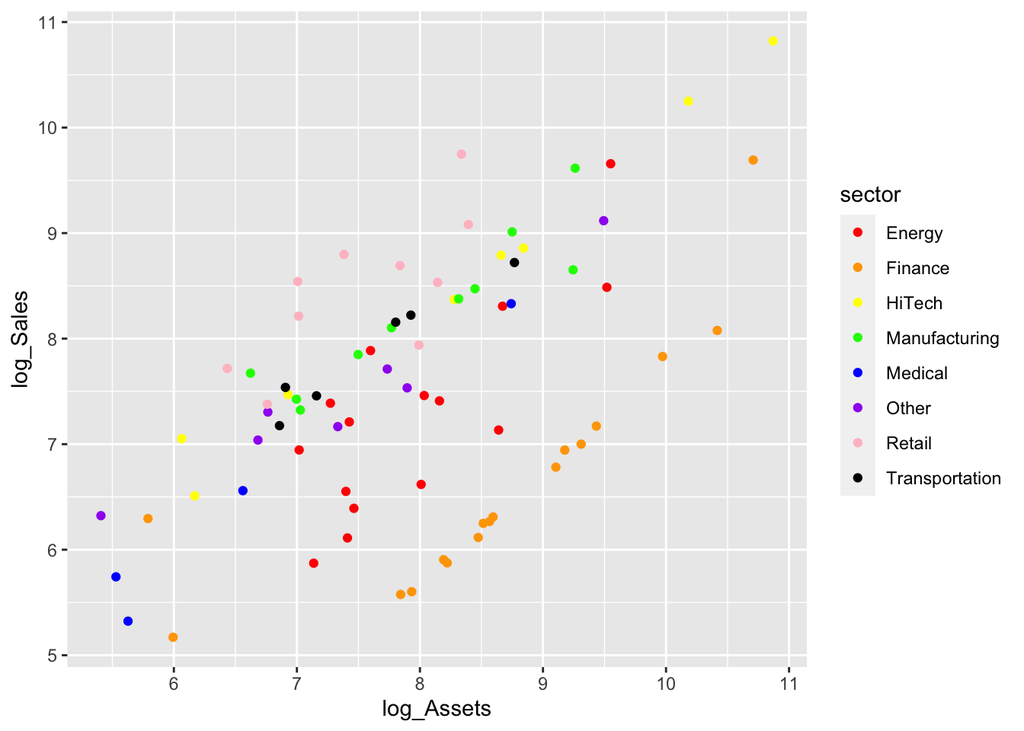

```r
colors <- c(
    "red",
    "orange",
    "yellow",
    "green",
    "blue",
    "purple",
    "pink",
    "black"
)

forbes500 <- read.csv("datasets/Forbes500.csv")
forbes500$log_Sales <- log(forbes500$Sales)
forbes500$log_Assets <- log(forbes500$Assets)
ggplot(data = forbes500, aes(x = log_Assets, y = log_Sales)) +
    geom_point(aes(color = sector)) +
    scale_color_manual(values = colors)
```

### Question 1 (b)

```r
# i. Interaction model
lm_interaction <- lm(
    log_Sales ~ log_Assets + sector + log_Assets:sector,
    data = forbes500
)
summary(lm_interaction)
```

```
##
## Call:
## lm(formula = log_Sales ~ log_Assets + sector + log_Assets:sector,
##     data = forbes500)
##
## Residuals:
##      Min       1Q   Median       3Q      Max
## -0.85091 -0.29289 -0.03143  0.20864  1.62471
##
## Coefficients:
##                                 Estimate Std. Error t value Pr(>|t|)
## (Intercept)                     -0.41669    1.33036  -0.313   0.7552
## log_Assets                       0.96963    0.16645   5.825 2.29e-07 ***
## sectorFinance                    1.21934    1.57447   0.774   0.4417
## sectorHiTech                     2.00228    1.61225   1.242   0.2190
## sectorManufacturing              3.08957    1.95259   1.582   0.1188
## sectorMedical                    1.08713    1.87636   0.579   0.5645
## sectorOther                      3.08076    1.80208   1.710   0.0924 .
## sectorRetail                     3.56154    2.25487   1.579   0.1194
## sectorTransportation             2.48700    2.68609   0.926   0.3582
## log_Assets:sectorFinance        -0.29118    0.19257  -1.512   0.1357
## log_Assets:sectorHiTech         -0.12964    0.19855  -0.653   0.5162
## log_Assets:sectorManufacturing  -0.27186    0.24346  -1.117   0.2685
## log_Assets:sectorMedical        -0.08999    0.25738  -0.350   0.7278
## log_Assets:sectorOther          -0.31583    0.23350  -1.353   0.1812
## log_Assets:sectorRetail         -0.26322    0.29275  -0.899   0.3721
## log_Assets:sectorTransportation -0.20239    0.34924  -0.580   0.5644
## ---
## Signif. codes:  0 '***' 0.001 '**' 0.01 '*' 0.05 '.' 0.1 ' ' 1
##
## Residual standard error: 0.5074 on 61 degrees of freedom
## Multiple R-squared:  0.858,  Adjusted R-squared:  0.8231
## F-statistic: 24.58 on 15 and 61 DF,  p-value: < 2.2e-16
```

```r
# ii. Additive model
lm_additive <- lm(log_Sales ~ log_Assets + sector, data = forbes500)
summary(lm_additive)
```

```
##
## Call:
## lm(formula = log_Sales ~ log_Assets + sector, data = forbes500)
##
## Residuals:
##     Min      1Q  Median      3Q     Max
## -0.8783 -0.3220 -0.0392  0.2105  1.8100
##
## Coefficients:
##                      Estimate Std. Error t value Pr(>|t|)
## (Intercept)           1.20481    0.43378   2.777 0.007073 **
## log_Assets            0.76577    0.05211  14.694  < 2e-16 ***
## sectorFinance        -1.15331    0.17868  -6.455 1.34e-08 ***
## sectorHiTech          0.99308    0.21738   4.568 2.13e-05 ***
## sectorManufacturing   0.92459    0.20221   4.572 2.10e-05 ***
## sectorMedical         0.21891    0.28731   0.762 0.448735
## sectorOther           0.63852    0.22903   2.788 0.006871 **
## sectorRetail          1.49307    0.20340   7.341 3.44e-10 ***
## sectorTransportation  0.87669    0.24008   3.652 0.000507 ***
## ---
## Signif. codes:  0 '***' 0.001 '**' 0.01 '*' 0.05 '.' 0.1 ' ' 1
##
## Residual standard error: 0.4953 on 68 degrees of freedom
## Multiple R-squared:  0.8492, Adjusted R-squared:  0.8315
## F-statistic: 47.86 on 8 and 68 DF,  p-value: < 2.2e-16
```

```r
# iii. Anova
anova(lm_additive, lm_interaction)
```

```
## Analysis of Variance Table
##
## Model 1: log_Sales ~ log_Assets + sector
## Model 2: log_Sales ~ log_Assets + sector + log_Assets:sector
##   Res.Df    RSS Df Sum of Sq      F Pr(>F)
## 1     68 16.681
## 2     61 15.704  7   0.97687 0.5421 0.7992
```

F-test: p-value is 0.7992, which is more than 0.05, so we fail to reject the null hypothesis. So the interaction terms are not needed in the model.

### Question 1 (c)

```r
# i. Fit the additive model
lm_additive <- lm(data = forbes500, log_Sales ~ sector + log_Assets)

# ii. Fit the simple linear regression model
lm_simple <- lm(data = forbes500, log_Sales ~ log_Assets)

# iii. anova
anova(lm_simple, lm_additive)
```

```
## Analysis of Variance Table
##
## Model 1: log_Sales ~ log_Assets
## Model 2: log_Sales ~ sector + log_Assets
##   Res.Df    RSS Df Sum of Sq      F    Pr(>F)
## 1     75 74.535
## 2     68 16.681  7    57.854 33.692 < 2.2e-16 ***
## ---
## Signif. codes:  0 '***' 0.001 '**' 0.01 '*' 0.05 '.' 0.1 ' ' 1
```

F-test: The p-value is < 2.2e-16, which means that we can reject the null hypothesis, so we should include the predictor `sector` in our model.

### Question 1 (d)

```r
contrasts(factor(forbes500$sector))
```

```
##                Finance HiTech Manufacturing Medical Other Retail Transportation
## Energy               0      0             0       0     0      0              0
## Finance              1      0             0       0     0      0              0
## HiTech               0      1             0       0     0      0              0
## Manufacturing        0      0             1       0     0      0              0
## Medical              0      0             0       1     0      0              0
## Other                0      0             0       0     1      0              0
## Retail               0      0             0       0     0      1              0
## Transportation       0      0             0       0     0      0              1
```

`Energy` is considered the baseline group.

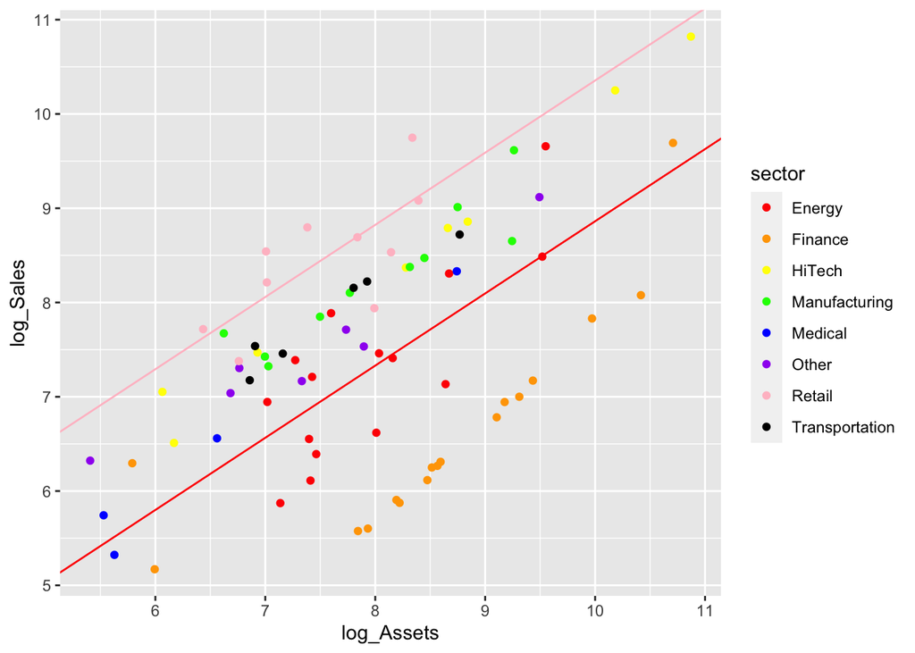

```r
coef <- lm_additive$coefficients

ggplot(data = forbes500, aes(x = log_Assets, y = log_Sales)) +
    geom_point(aes(color = sector)) +
    geom_abline(slope = coef[9], intercept = coef[1], color = colors[1]) +
    geom_abline(
        slope = coef[9],
        intercept = coef[1] + coef[7],
        color = colors[7]
    ) +
    scale_color_manual(values = colors)
```

### Question 2 (a)

```r
table(Angell$region)
```

```
##
##  E MW  S  W
##  9 14 14  6
```

This is an unbalanced one-way ANOVA, as seen in the table above.

### Question 2 (b)

```r
Angell %>%
    group_by(region) %>%
    summarise(mean_mobility = mean(mobility))
```

```
## # A tibble: 4 × 2
##   region mean_mobility
##   <fct>          <dbl>
## 1 E               15.9
## 2 MW              26.1
## 3 S               32.5
## 4 W               37.4
```

The means of the four groups are as follows:  
East: 15.9  
Midwest: 26.1  
South:32.5  
West: 37.4

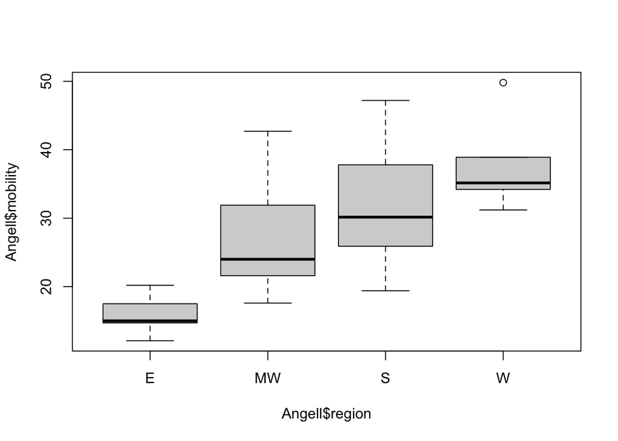

```r
boxplot(Angell$mobility ~ Angell$region)
```

### Question 2 (c)

```r
leveneTest(Angell$mobility, Angell$region)
```

```
## Levene's Test for Homogeneity of Variance (center = median)
##       Df F value  Pr(>F)
## group  3  2.4694 0.07625 .
##       39
## ---
## Signif. codes:  0 '***' 0.001 '**' 0.01 '*' 0.05 '.' 0.1 ' ' 1
```

H0: $\sigma$<sub>E</sub> = $\sigma$<sub>MW</sub> = $\sigma$<sub>S</sub> = $\sigma$<sub>W</sub> Ha: at least one $\sigma$ is different.

The p-value Levene’s Test is 0.07625, which is (barely) higher than 0.05, so we fail to reject the null hypothesis. We conclude that constant variance is reasonable.

### Question 2 (d)

#### Baseline = 0 constraint (default)

```r
contrasts(Angell$region)
```

```
##    MW S W
## E   0 0 0
## MW  1 0 0
## S   0 1 0
## W   0 0 1
```

```r
summary(aov(data = Angell, mobility ~ region))
```

```
##             Df Sum Sq Mean Sq F value   Pr(>F)
## region       3   2172   724.0   15.24 1.02e-06 ***
## Residuals   39   1853    47.5
## ---
## Signif. codes:  0 '***' 0.001 '**' 0.01 '*' 0.05 '.' 0.1 ' ' 1
```

RegSS = 2171.861  
RSS = 1852.629

```r
lm_mobility_on_region <- lm(data = Angell, mobility ~ region)
summary(lm_mobility_on_region)
```

```
##
## Call:
## lm(formula = mobility ~ region, data = Angell)
##
## Residuals:
##     Min      1Q  Median      3Q     Max
## -13.057  -4.607  -1.200   3.971  16.643
##
## Coefficients:
##             Estimate Std. Error t value Pr(>|t|)
## (Intercept)   15.900      2.297   6.921 2.75e-08 ***
## regionMW      10.157      2.945   3.449  0.00136 **
## regionS       16.557      2.945   5.623 1.73e-06 ***
## regionW       21.500      3.633   5.919 6.72e-07 ***
## ---
## Signif. codes:  0 '***' 0.001 '**' 0.01 '*' 0.05 '.' 0.1 ' ' 1
##
## Residual standard error: 6.892 on 39 degrees of freedom
## Multiple R-squared:  0.5397, Adjusted R-squared:  0.5043
## F-statistic: 15.24 on 3 and 39 DF,  p-value: 1.025e-06
```

The slope of the dummy regressor for region Southeast (S) is 16.557. This is the difference between the mean of the Southeast region (S)and the mean of the baseline region (E). In our case, the slope of 16.557 means that the estimated mean mobility for cities in the Southeast (S) region is the baseline (E) estimate of 15.900 plus our slope, which equals 32.457

#### Sum-to-zero constraint

```r
contrasts(Angell$region) <- contr.sum(levels(Angell$region)) # Apply sum-to-zero
contrasts(Angell$region)
```

```
##    [,1] [,2] [,3]
## E     1    0    0
## MW    0    1    0
## S     0    0    1
## W    -1   -1   -1
```

```r
aov(data = Angell, mobility ~ region)
```

```
## Call:
##    aov(formula = mobility ~ region, data = Angell)
##
## Terms:
##                   region Residuals
## Sum of Squares  2171.861  1852.629
## Deg. of Freedom        3        39
##
## Residual standard error: 6.892264
## Estimated effects may be unbalanced
```

With the sum-to-zero constraint,  
RegSS = 2171.861  
RSS = 1852.629

These are the same numbers as with the baseline = 0 constraint!

```r
lm_mobility_on_region_sum_to_zero <- lm(data = Angell, mobility ~ region)
summary(lm_mobility_on_region_sum_to_zero)
```

```
##
## Call:
## lm(formula = mobility ~ region, data = Angell)
##
## Residuals:
##     Min      1Q  Median      3Q     Max
## -13.057  -4.607  -1.200   3.971  16.643
##
## Coefficients:
##             Estimate Std. Error t value Pr(>|t|)
## (Intercept)   27.954      1.118  25.014  < 2e-16 ***
## region1      -12.054      1.972  -6.113 3.61e-07 ***
## region2       -1.896      1.716  -1.105   0.2759
## region3        4.504      1.716   2.624   0.0123 *
## ---
## Signif. codes:  0 '***' 0.001 '**' 0.01 '*' 0.05 '.' 0.1 ' ' 1
##
## Residual standard error: 6.892 on 39 degrees of freedom
## Multiple R-squared:  0.5397, Adjusted R-squared:  0.5043
## F-statistic: 15.24 on 3 and 39 DF,  p-value: 1.025e-06
```

In this case, the constraint we imposed means the dummy variable for region Southeast (S) is region 3. The slope of this dummy regressor is 4.504. This is the difference between the mean for the Southeast region (S) and the grand mean of all regions. In our case, the slope of 4.504 means that the estimated mean mobility for cities in the Southeast (S) region is 4.504 above the grand mean. If we do the math, this comes out to 27.954 + 4.504 = 32.458. This is the same value we got in the previous part!

### Question 2 (e)

```r
anova(lm_mobility_on_region)
```

```
## Analysis of Variance Table
##
## Response: mobility
##           Df Sum Sq Mean Sq F value    Pr(>F)
## region     3 2171.9  723.95   15.24 1.025e-06 ***
## Residuals 39 1852.6   47.50
## ---
## Signif. codes:  0 '***' 0.001 '**' 0.01 '*' 0.05 '.' 0.1 ' ' 1
```

H0: $\beta$<sub>regionMW</sub> = $\beta$<sub>regionS</sub> = $\beta$<sub>regionW</sub> = 0  
Ha: At least one $\beta$ differs.

Here, the p-value for our f test is 1.025e-06. This value is less than 0.05, so we reject the null hypothesis at a confidence level of 0.05. The variable `region` is significant.

### Question 2 (f)

```r
TukeyHSD(aov(lm_mobility_on_region))
```

```
##   Tukey multiple comparisons of means
##     95% family-wise confidence level
##
## Fit: aov(formula = lm_mobility_on_region)
##
## $region
##           diff       lwr      upr     p adj
## MW-E 10.157143  2.255441 18.05884 0.0071580
## S-E  16.557143  8.655441 24.45884 0.0000101
## W-E  21.500000 11.752557 31.24744 0.0000039
## S-MW  6.400000 -0.590254 13.39025 0.0830803
## W-MW 11.342857  2.318478 20.36724 0.0088094
## W-S   4.942857 -4.081522 13.96724 0.4650461
```

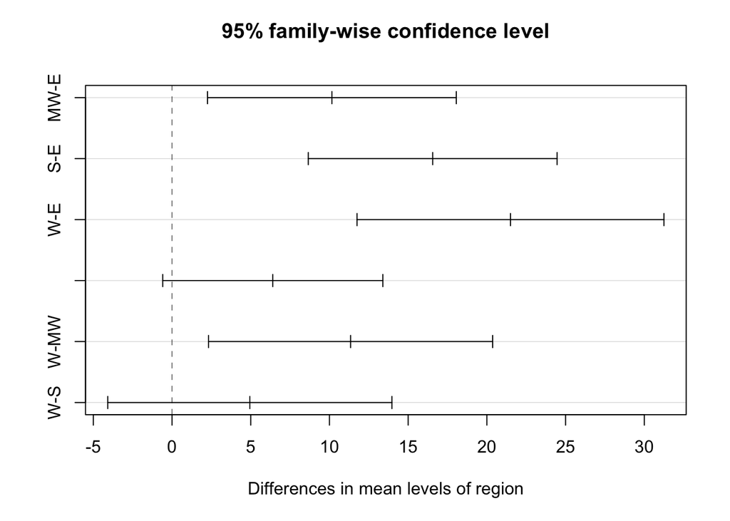

```r
plot(TukeyHSD(aov(lm_mobility_on_region)))
```

The Tukey test indicates that the differences between the following regions are significant at the 0.05 level:  
MW-E  
S-E  
W-E  
W-MW

The following differences are not significant:  
S-MW  
W-S

### Question 3 (a)

```r
advertising <- read.csv("datasets/advertising2.csv")

# i. reorder the factor levels
advertising$Day <- factor(advertising$Day, levels = c(
    "Monday",
    "Tuesday",
    "Wednesday",
    "Thursday",
    "Friday"
))
advertising$Section <- factor(advertising$Section)
levels(advertising$Day)
```

```
## [1] "Monday"    "Tuesday"   "Wednesday" "Thursday"  "Friday"
```

```r
# ii. Change to sum-to-zero
contrasts(advertising$Day) <- contr.sum(levels(advertising$Day))
contrasts(advertising$Day)
```

```
##           [,1] [,2] [,3] [,4]
## Monday       1    0    0    0
## Tuesday      0    1    0    0
## Wednesday    0    0    1    0
## Thursday     0    0    0    1
## Friday      -1   -1   -1   -1
```

```r
# iii. Load the `car` library
library(car)
```

### Question 3 (b)

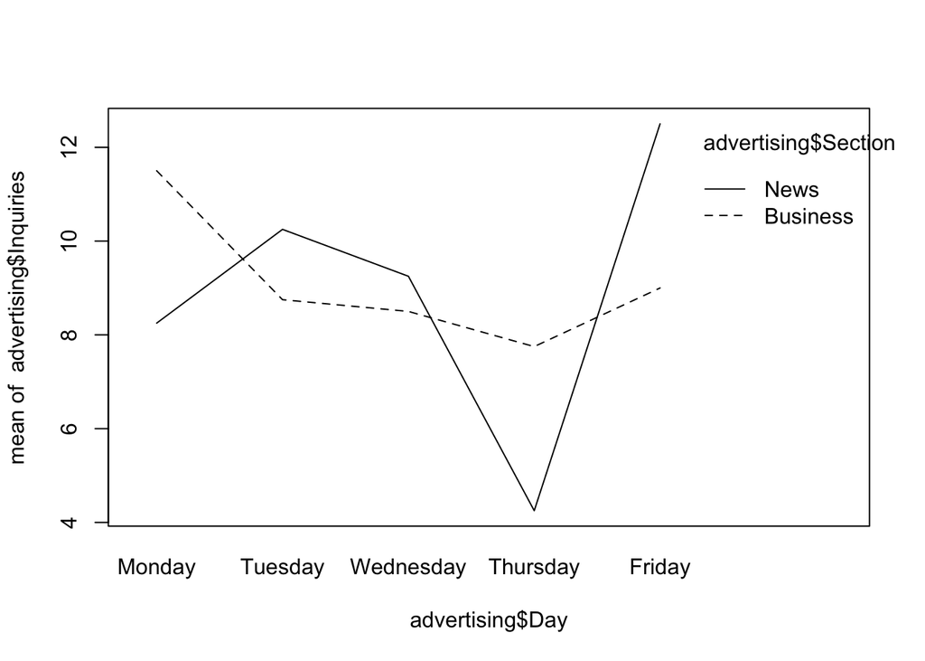

```r
interaction.plot(advertising$Day, advertising$Section, advertising$Inquiries)
```

The two lines on the plot are not parallel. This indicates that there is a significant interaction between the two factors (day and section).

### Question 3 (c)

```r
lm_with_interaction <- lm(
    data = advertising,
    Inquiries ~ Day + Section + Day:Section
)

Anova(lm_with_interaction, type = "III")
```

```
## Anova Table (Type III tests)
##
## Response: Inquiries
##              Sum Sq Df  F value    Pr(>F)
## (Intercept) 1656.20  1 895.2432 < 2.2e-16 ***
## Day           32.30  4   4.3649    0.0067 **
## Section        0.40  1   0.2162    0.6453
## Day:Section   75.35  4  10.1824 2.493e-05 ***
## Residuals     55.50 30
## ---
## Signif. codes:  0 '***' 0.001 '**' 0.01 '*' 0.05 '.' 0.1 ' ' 1
```

According to this ANOVA table, the p-value for f-test for the interaction between Day and Section is 2.493e-05, which is less than 0.05 and therefore significant.

### Question 3 (d)

```r
# To test if there is a significant difference in number of inquiries between
#   the two section on Monday, we do a multiple comparison.
advertising$grouping <- advertising$Day:advertising$Section

contrasts(advertising$grouping) <- contr.sum(levels(advertising$grouping))

contrasts(advertising$grouping)
```

```
##                    [,1] [,2] [,3] [,4] [,5] [,6] [,7] [,8] [,9]
## Monday:Business       1    0    0    0    0    0    0    0    0
## Monday:News           0    1    0    0    0    0    0    0    0
## Tuesday:Business      0    0    1    0    0    0    0    0    0
## Tuesday:News          0    0    0    1    0    0    0    0    0
## Wednesday:Business    0    0    0    0    1    0    0    0    0
## Wednesday:News        0    0    0    0    0    1    0    0    0
## Thursday:Business     0    0    0    0    0    0    1    0    0
## Thursday:News         0    0    0    0    0    0    0    1    0
## Friday:Business       0    0    0    0    0    0    0    0    1
## Friday:News          -1   -1   -1   -1   -1   -1   -1   -1   -1
```

```r
levels(advertising$Day:advertising$Section)
```

```
##  [1] "Monday:Business"    "Monday:News"        "Tuesday:Business"
##  [4] "Tuesday:News"       "Wednesday:Business" "Wednesday:News"
##  [7] "Thursday:Business"  "Thursday:News"      "Friday:Business"
## [10] "Friday:News"
```

```r
linearHypothesis(
    lm(data = advertising, Inquiries ~ grouping),
    c(0, 1, -1, 0, 0, 0, 0, 0, 0, 0),
    rhs = 0
)
```

```
## Linear hypothesis test
##
## Hypothesis:
## grouping1 - grouping2 = 0
##
## Model 1: restricted model
## Model 2: Inquiries ~ grouping
##
##   Res.Df    RSS Df Sum of Sq      F   Pr(>F)
## 1     31 76.625
## 2     30 55.500  1    21.125 11.419 0.002032 **
## ---
## Signif. codes:  0 '***' 0.001 '**' 0.01 '*' 0.05 '.' 0.1 ' ' 1
```

H0: $\mu$ + $\alpha$<sub>1</sub> = $\mu$ + $\alpha$<sub>2</sub>  
Ha: $\mu$ + $\alpha$<sub>1</sub> != $\mu$ + $\alpha$<sub>2</sub>

We reject the null, which means that the two group means are different.